# Psych 254 W15 PS #2

# Part 2: Diving into real data: Sklar et al. (2012)

Sklar et al. (2012) claims evidence for unconscious arithmetic processing. We’re going to do a reanalysis of their Experiment 6, which is the primary piece of evidence for that claim. The data are generously contributed by Asael Sklar.

First let’s set up a few preliminaries.

```r
library(tidyr)
library(dplyr)
sem <- function(x) {sd(x) / sqrt(length(x))}
ci95 <- function(x) {sem(x) * 1.96}
```

## Data Prep

First read in two data files and subject info. A and B refer to different trial order counterbalances.

```r
setwd("~/ESmith_psych254/analyses")
subinfo <- read.csv("../data/sklar_expt6_subinfo_corrected.csv")
d.a <- read.csv("../data/sklar_expt6a_corrected.csv")
d.b <- read.csv("../data/sklar_expt6b_corrected.csv")
```

Gather these datasets into long form and get rid of the Xs in the headers.

```r
d.a <- d.a %>%
  gather(id,time,
         X1:X21)
d.b <- d.b %>%
  gather(id,time,
         X22:X42)
```

Bind these together. Check out `bind_rows`.

```r
d <- bind_rows(d.a,d.b)
```

Merge these with subject info. You will need to look into merge and its relatives, `left_join` and `right_join`. Call this dataframe `d`, by convention.

```r
d$id <- gsub("X","",d$id) # get rid of X's to merge
d <- merge(subinfo,d,by.x="subid","id") # join is much faster- look into this
```

Clean up the factor structure.

```r
d$presentation.time <- factor(d$presentation.time)
d$operand <- factor(d$operand)
levels(d$operand) <- c("addition","subtraction")
```

## Data Analysis Preliminaries

Examine the basic properties of the dataset. First, take a histogram.

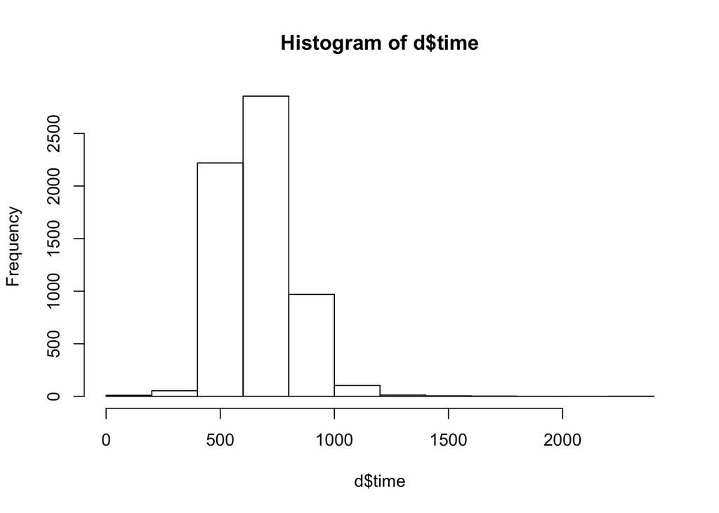

```r
hist(d$time)
```

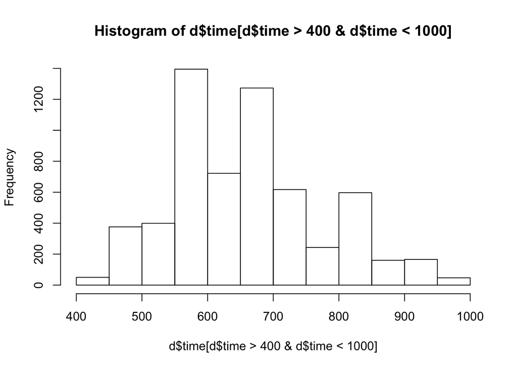

```r
hist(d$time[d$time > 400 & d$time < 1000])
```

Challenge question: what is the sample rate of the input device they are using to gather RTs?

```r
stem(d$time[d$time >600 & d$time <800])
```

```
##
##   The decimal point is 1 digit(s) to the right of the |
##
##   62 | 77777777777777777777777777777777777777888888888888888888888888888888+642
##   63 |
##   64 |
##   65 |
##   66 | 33333333333333333333333333333333333333333333333333333333333333344444+702
##   67 |
##   68 |
##   69 | 99999999999999999999999999999999999999999999999999999999999999999999+19
##   70 | 00000000000000000000000000000000000000000000000000000000000000000000+391
##   71 |
##   72 |
##   73 | 55555555555555555555555555555555555555555555555555555555555555555555+458
##   74 |
##   75 |
##   76 | 77777777777777777777777777777777777777777777777777788888888888888888+163
```

```r
663-627
```

```
## [1] 36
```

```r
699-663
```

```
## [1] 36
```

```r
#etc.
```

Looks like the refresh frame rate is about 36 milliseconds.

Sklar et al. did two manipulation checks. Subjective - asking participants whether they saw the primes - and objective - asking them to report the parity of the primes (even or odd) to find out if they could actually read the primes when they tried. Examine both the unconscious and conscious manipulation checks (this information is stored in subinfo). What do you see? Are they related to one another?

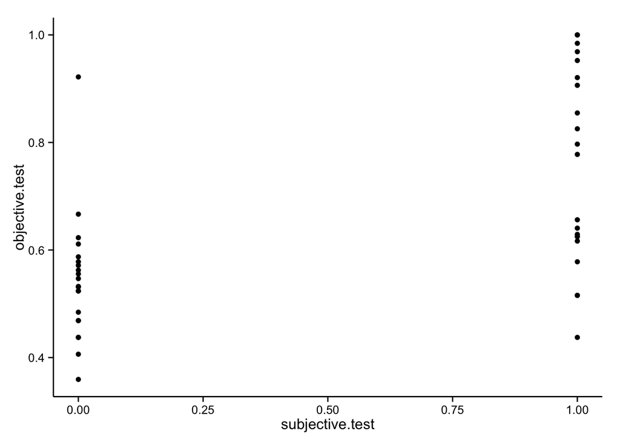

```r
# First let's check out the relationship between the subjective and objective primes
ggplot(subinfo,aes(x=subjective.test,y=objective.test)) +
  geom_point() +
  theme_classic()
```

Visually, it certainly looks like those that reported seeing the problems were much better at the objective tests, were those that did not see it were no better than chance. But let’s test this.

```r
summary(lm(objective.test ~ as.factor(subjective.test), data=subinfo))
```

```
##
## Call:
## lm(formula = objective.test ~ as.factor(subjective.test), data = subinfo)
##
## Residuals:
##     Min      1Q  Median      3Q     Max
## -0.3162 -0.1111 -0.0032  0.0781  0.3791
##
## Coefficients:
##                             Estimate Std. Error t value Pr(>|t|)
## (Intercept)                   0.5428     0.0332   16.33   <2e-16 ***
## as.factor(subjective.test)1   0.2109     0.0470    4.49    6e-05 ***
## ---
## Signif. codes:  0 '***' 0.001 '**' 0.01 '*' 0.05 '.' 0.1 ' ' 1
##
## Residual standard error: 0.152 on 40 degrees of freedom
## Multiple R-squared:  0.335,  Adjusted R-squared:  0.318
## F-statistic: 20.1 on 1 and 40 DF,  p-value: 5.97e-05
```

We verify that objective measures of parity are better when participants report seeing the primes.

OK, let’s turn back to the measure and implement Sklar et al.’s exclusion criterion. You need to have said you couldn’t see (subjective test) and also be not significantly above chance on the objective test (< .6 correct). Call your new data frame `ds`.

```r
ds <- d %>%
  filter(subjective.test == 0 &
         objective.test < .6)
```

It looks like only 17 out of the 42 participants are included in data analysis. That’s pretty fishy right there…

## Sklar et al.’s analysis

Sklar et al. show a plot of a “facilitation effect” - the time to respond to incongruent primes minus the time to respond to congruent primes. They then show plot this difference score for the subtraction condition and for the two presentation times they tested. Try to reproduce this analysis.

HINT: first take averages within subjects, then compute your error bars across participants, using the `sem` function (defined above).

```r
# first we aggregate by subject by taking their mean scores from incongruent and congruent
p1 <- ds %>%
  group_by(subid,presentation.time,congruent,operand) %>%
  summarize(time = mean(time,na.rm=T)) %>%
  spread(congruent,time) %>%
  mutate(diff = no - yes) %>%
  group_by(presentation.time,operand) %>%
  summarize(mean = mean(diff),
            sem = sem(diff),
            ci = ci95(diff))
```

Now plot this summary, giving more or less the bar plot that Sklar et al. gave (though I would keep operation as a variable here. Make sure you get some error bars on there (e.g. `geom_errorbar` or `geom_linerange`).

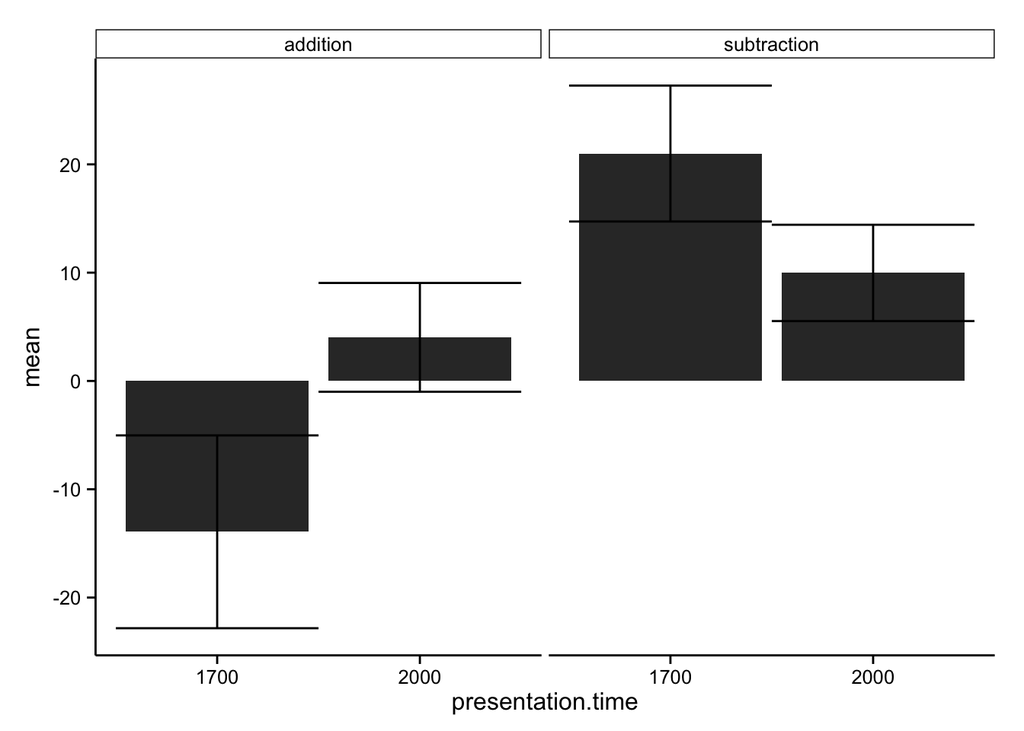

```r
ggplot(p1, aes(x=presentation.time, y=mean)) +
  theme_classic() +
  geom_bar(stat="identity") +
  geom_errorbar(aes(ymax = mean + sem, ymin=mean - sem), width=1) +
  facet_grid(.~operand)
```

What do you see here? How close is it to what Sklar et al. report? Do the error bars match? How do you interpret these data?

The error bars do not seem to match at all. As discussed in class, the error bars reported are actualy 1/2 the standard error.

Challenge problem: verify Sklar et al.’s claim about the relationship between RT and the objective manipulation check.

```r
p2 <- ds %>%
  filter(operand == "subtraction") %>%
  group_by(subid,presentation.time,congruent) %>%
  summarize(time = mean(time,na.rm=T)) %>%
  spread(congruent,time) %>%
  mutate(diff = no - yes)

p2b <- merge(subinfo,p2)
summary(lm(diff ~ I(objective.test-.5),data=p2b)) #
```

```
##
## Call:
## lm(formula = diff ~ I(objective.test - 0.5), data = p2b)
##
## Residuals:
##    Min     1Q Median     3Q    Max
## -21.48  -8.64  -1.55   8.35  37.11
##
## Coefficients:
##                         Estimate Std. Error t value Pr(>|t|)
## (Intercept)                14.78       3.78    3.91   0.0014 **
## I(objective.test - 0.5)    86.85      58.97    1.47   0.1615
## ---
## Signif. codes:  0 '***' 0.001 '**' 0.01 '*' 0.05 '.' 0.1 ' ' 1
##
## Residual standard error: 15.5 on 15 degrees of freedom
## Multiple R-squared:  0.126,  Adjusted R-squared:  0.0681
## F-statistic: 2.17 on 1 and 15 DF,  p-value: 0.161
```

We verify that the there is a facilitation when the objective test measure is at chance, t(15)=3.91, p=.001, and there is a non-significant effect of the objective.test, t(15)=1.47, p=.16 .

## Your own analysis

Show us what you would do with these data, operating from first principles. What’s the fairest plot showing a test of Sklar et al.’s original hypothesis that people can do arithmetic “non-consciously”?

Without limiting the data at all, or taking only the subtraction, let’s do the same plots as before.

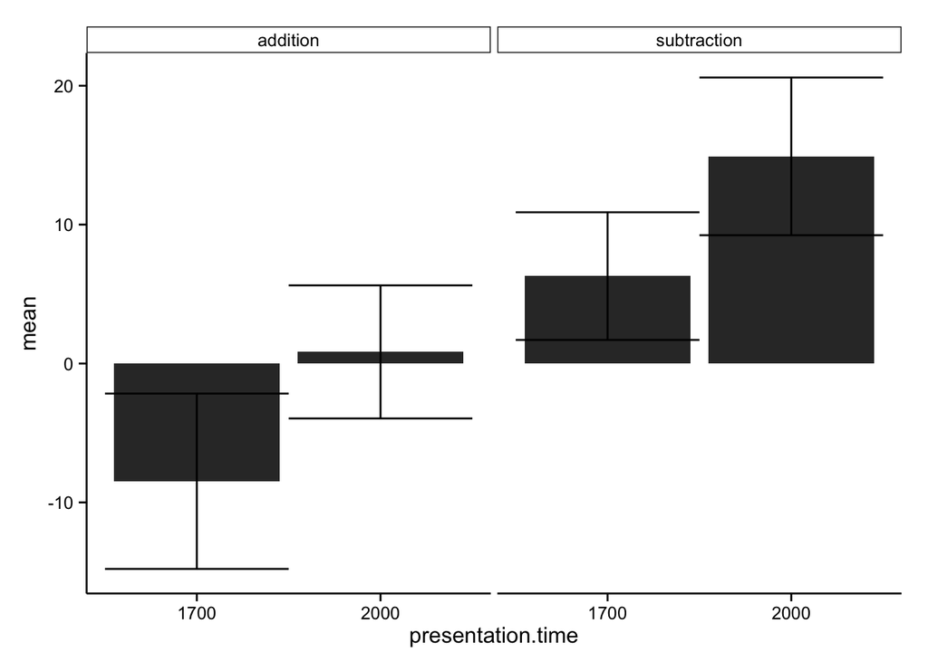

```r
p3 <- d %>%
  group_by(subid,presentation.time,congruent,operand) %>%
  summarize(time = mean(time,na.rm=T)) %>%
  spread(congruent,time) %>%
  mutate(diff = no - yes) %>%
  group_by(presentation.time,operand) %>%
  summarize(mean = mean(diff),
            sem = sem(diff),
            ci = ci95(diff))
ggplot(p3, aes(x=presentation.time, y=mean)) +
  theme_classic() +
  geom_bar(stat="identity") +
  geom_errorbar(aes(ymax = mean + sem, ymin=mean - sem), width=1) +
  facet_grid(.~operand)
```

Now it does seem reasonable to limit the data if people report seeing the numbers. That would suggest that this is quite conscious. However, it is odd for the original paper to limit participants who perform better than chance on telling whether the resulting number is even or odd. After all, if they are able to facilitate their solving the math problem, you’d think the same processes would allow them to determine parity.

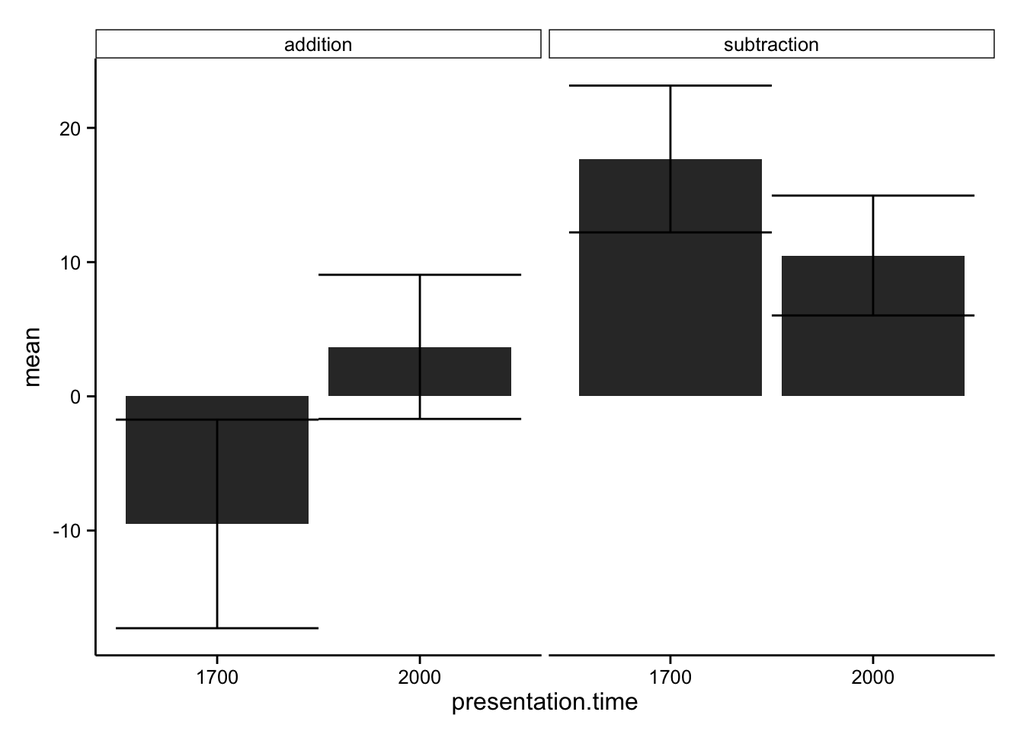

```r
p4 <- d %>%
  filter(subjective.test == 0) %>%
  group_by(subid,presentation.time,congruent,operand) %>%
  summarize(time = mean(time,na.rm=T)) %>%
  spread(congruent,time) %>%
  mutate(diff = no - yes) %>%
  group_by(presentation.time,operand) %>%
  summarize(mean = mean(diff),
            sem = sem(diff),
            ci = ci95(diff))
ggplot(p4, aes(x=presentation.time, y=mean)) +
  theme_classic() +
  geom_bar(stat="identity") +
  geom_errorbar(aes(ymax = mean + sem, ymin=mean - sem), width=1) +
  facet_grid(.~operand)
```

Challenge problem: Do you find any statistical support for Sklar et al.’s findings?

```r
p4b <- d %>%
  filter(subjective.test == 0 & operand == "subtraction") %>%
  group_by(subid,presentation.time,congruent,operand) %>%
  summarize(time = mean(time,na.rm=T)) %>%
  spread(congruent,time) %>%
  mutate(diff = no - yes)

tt <- t.test(p4b$diff); tt
```

```
##
##  One Sample t-test
##
## data:  p4b$diff
## t = 3.972, df = 20, p-value = 0.0007513
## alternative hypothesis: true mean is not equal to 0
## 95 percent confidence interval:
##   6.608 21.224
## sample estimates:
## mean of x
##     13.92
```

If we use the same sort of statistics as in the paper, we do find not limiting the data on objective measures of parity still shows a significant facilitation effect for subtraction problems. However, if we did this analysis using an lmer model, with a random intercept and slope for participant, we do not find the same effect.

```r
library(lme4)
library(lmerTest)
ps2 <- d %>% filter(subjective.test == 0)
summary(lmer(time ~ operand + congruent + (operand+congruent|subid), data=ps2))
```

```
## Linear mixed model fit by REML ['merModLmerTest']
## Formula: time ~ operand + congruent + (operand + congruent | subid)
##    Data: ps2
##
## REML criterion at convergence: 38260
##
## Scaled residuals:
##    Min     1Q Median     3Q    Max
## -4.369 -0.613 -0.079  0.532 14.522
##
## Random effects:
##  Groups   Name               Variance Std.Dev. Corr
##  subid    (Intercept)         6617.58  81.35
##           operandsubtraction  1316.52  36.28   0.29
##           congruentyes           3.74   1.93   0.81 0.80
##  Residual                    12079.93 109.91
## Number of obs: 3118, groups: subid, 21
##
## Fixed effects:
##                    Estimate Std. Error     df t value Pr(>|t|)
## (Intercept)          691.75      18.07  20.00   38.29   <2e-16 ***
## operandsubtraction   -23.82       8.84  20.00   -2.69    0.014 *
## congruentyes          -5.27       3.96 667.00   -1.33    0.184
## ---
## Signif. codes:  0 '***' 0.001 '**' 0.01 '*' 0.05 '.' 0.1 ' ' 1
##
## Correlation of Fixed Effects:
##             (Intr) oprnds
## oprndsbtrct  0.209
## congruentys -0.023  0.076
```

On first pass, it looks like subtraction is even quicker than addition, which does not support the claim that subtraction was harder. So lets take that term out of the equation.

```r
summary(lmer(time ~ congruent + (congruent|subid), data=ps2))
```

```
## Linear mixed model fit by REML ['merModLmerTest']
## Formula: time ~ congruent + (congruent | subid)
##    Data: ps2
##
## REML criterion at convergence: 38352
##
## Scaled residuals:
##    Min     1Q Median     3Q    Max
## -4.509 -0.645 -0.097  0.538 14.547
##
## Random effects:
##  Groups   Name         Variance Std.Dev. Corr
##  subid    (Intercept)   7759.32  88.09
##           congruentyes     2.34   1.53   1.00
##  Residual              12534.74 111.96
## Number of obs: 3118, groups: subid, 21
##
## Fixed effects:
##              Estimate Std. Error     df t value Pr(>|t|)
## (Intercept)    680.31      19.43  20.00   35.01   <2e-16 ***
## congruentyes    -5.39       4.02 985.00   -1.34     0.18
## ---
## Signif. codes:  0 '***' 0.001 '**' 0.01 '*' 0.05 '.' 0.1 ' ' 1
##
## Correlation of Fixed Effects:
##             (Intr)
## congruentys -0.021
```

```r
pt(1.3,15,lower.tail=F)*2
```

```
## [1] 0.2132
```

So we leave that out of our final summary, and find that there is no significant facilitation in congruent trials compared to incongruent trials, t=1.34, p=.18.